# IODS course project

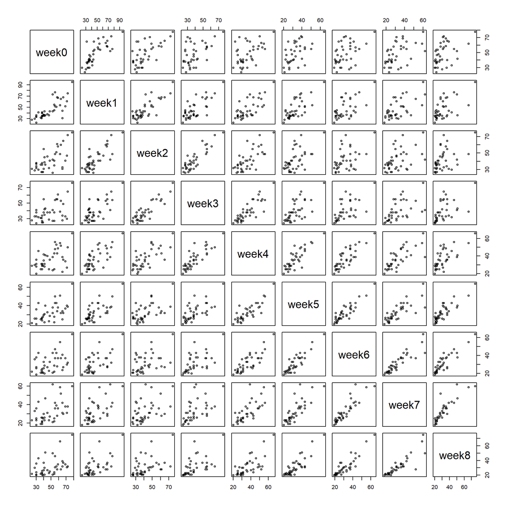

```r
#Drawing the Fig 9.3
pairs(BPRS[, 3:11], cex = 0.7)
```

##### **FIGURE 9.3** Scatterplot matrix of repeated measures in BPRS data.

Next we proceed fitting linear mixed models to the BPRS data. First step is to fit a random interept model with week and treatment as explanatory variables (Table 9.4). Random intercept model means that we allow the intercepts of the fitted regression vary between subjects. From the results we see that variance of intercepts is 47.41 whereas residual variance is 104.21. Even though the residal variance is higher than the variance of intercepts, the variance of intercepts is still considerable. And also based on graphical examination of the data, it is reasonable to assume intercepts to vary between sucjects. The parameter estimates for week and treatment did not change much compared to the independence model (Table 9.3).

##### **TABLE 9.4** Results from fitting random intercept model, with week and treatment as explanatory variables, to BPRS data

```r
#Table 9.4
library("lme4")
BPRS_ref <- lmer(bprs ~ week + treatment + (1 | subject), data = BPRSL, REML = FALSE)
summary(BPRS_ref)
```

```
## Linear mixed model fit by maximum likelihood  ['lmerMod']
## Formula: bprs ~ week + treatment + (1 | subject)
##    Data: BPRSL
##
##      AIC      BIC   logLik deviance df.resid
##   2748.7   2768.1  -1369.4   2738.7      355
##
## Scaled residuals:
##     Min      1Q  Median      3Q     Max
## -3.0481 -0.6749 -0.1361  0.4813  3.4855
##
## Random effects:
##  Groups   Name        Variance Std.Dev.
##  subject  (Intercept)  47.41    6.885
##  Residual             104.21   10.208
## Number of obs: 360, groups:  subject, 20
##
## Fixed effects:
##             Estimate Std. Error t value
## (Intercept)  46.4539     1.9090  24.334
## week         -2.2704     0.2084 -10.896
## treatment2    0.5722     1.0761   0.532
##
## Correlation of Fixed Effects:
##            (Intr) week
## week       -0.437
## treatment2 -0.282  0.000
```

##### **TABLE 9.5** Results from fitting random intercept and slope model, with week and treatment as explanatory variables, to BPRS data

```r
# Table 9.5
BPRS_ref2 <- lmer(bprs ~ week + treatment + (week | subject), data = BPRSL, REML = FALSE)
summary(BPRS_ref2)
```

```
## Linear mixed model fit by maximum likelihood  ['lmerMod']
## Formula: bprs ~ week + treatment + (week | subject)
##    Data: BPRSL
##
##      AIC      BIC   logLik deviance df.resid
##   2745.4   2772.6  -1365.7   2731.4      353
##
## Scaled residuals:
##     Min      1Q  Median      3Q     Max
## -2.8919 -0.6194 -0.0691  0.5531  3.7976
##
## Random effects:
##  Groups   Name        Variance Std.Dev. Corr
##  subject  (Intercept) 64.8202  8.0511
##           week         0.9608  0.9802   -0.51
##  Residual             97.4307  9.8707
## Number of obs: 360, groups:  subject, 20
##
## Fixed effects:
##             Estimate Std. Error t value
## (Intercept)  46.4539     2.1052  22.066
## week         -2.2704     0.2977  -7.626
## treatment2    0.5722     1.0405   0.550
##
## Correlation of Fixed Effects:
##            (Intr) week
## week       -0.582
## treatment2 -0.247  0.000
```

```r
anova(BPRS_ref2, BPRS_ref)
```

```
## Data: BPRSL
## Models:
## BPRS_ref: bprs ~ week + treatment + (1 | subject)
## BPRS_ref2: bprs ~ week + treatment + (week | subject)
##           Df    AIC    BIC  logLik deviance  Chisq Chi Df Pr(>Chisq)
## BPRS_ref   5 2748.7 2768.1 -1369.4   2738.7
## BPRS_ref2  7 2745.4 2772.6 -1365.7   2731.4 7.2721      2    0.02636 *
## ---
## Signif. codes:  0 '***' 0.001 '**' 0.01 '*' 0.05 '.' 0.1 ' ' 1
```

The final step is to fit a random intercept and slope model allowing a treatmet + week interaction (Table 9.6). Now we can see some changes also in parameter estimates of fixed effect. However, the interaction between week and treatment does not appear very strong (beta 0.72 s.e. 0.40, T-value 1.785). Also when this final model is compared with previous model in ANOVA, it does not appear have significantly better fit to the data (p=0.075). The final conlusion from the models is that bprs scores decrease over time, but there is no difference between treatment groups.

##### **TABLE 9.6** Results from fitting the random intercept and slope model that allows for a treatment + week interaction to BPRS data

```r
# TAble 9.6
BPRS_ref3 <- lmer(bprs ~ week*treatment + (week | subject), data = BPRSL, REML = FALSE)
summary(BPRS_ref3)
```

```
## Linear mixed model fit by maximum likelihood  ['lmerMod']
## Formula: bprs ~ week * treatment + (week | subject)
##    Data: BPRSL
##
##      AIC      BIC   logLik deviance df.resid
##   2744.3   2775.4  -1364.1   2728.3      352
##
## Scaled residuals:
##     Min      1Q  Median      3Q     Max
## -3.0512 -0.6271 -0.0767  0.5288  3.9260
##
## Random effects:
##  Groups   Name        Variance Std.Dev. Corr
##  subject  (Intercept) 65.0016  8.0624
##           week         0.9688  0.9843   -0.51
##  Residual             96.4699  9.8219
## Number of obs: 360, groups:  subject, 20
##
## Fixed effects:
##                 Estimate Std. Error t value
## (Intercept)      47.8856     2.2522  21.262
## week             -2.6283     0.3589  -7.323
## treatment2       -2.2911     1.9090  -1.200
## week:treatment2   0.7158     0.4010   1.785
##
## Correlation of Fixed Effects:
##             (Intr) week   trtmn2
## week        -0.650
## treatment2  -0.424  0.469
## wek:trtmnt2  0.356 -0.559 -0.840
```

```r
anova(BPRS_ref3, BPRS_ref2)
```

```
## Data: BPRSL
## Models:
## BPRS_ref2: bprs ~ week + treatment + (week | subject)
## BPRS_ref3: bprs ~ week * treatment + (week | subject)
##           Df    AIC    BIC  logLik deviance  Chisq Chi Df Pr(>Chisq)
## BPRS_ref2  7 2745.4 2772.6 -1365.7   2731.4
## BPRS_ref3  8 2744.3 2775.4 -1364.1   2728.3 3.1712      1    0.07495 .
## ---
## Signif. codes:  0 '***' 0.001 '**' 0.01 '*' 0.05 '.' 0.1 ' ' 1
```

Fitted cahnges in bprs scores from the final model and observed bprs changes are plotted in the figure 9.4. The figures support the conlusions made from the linear mixed models. The individual slopes show a clear decrease in bprs scores over time (weeks), but there seems to be no difference between the treatment groups 1 and 2. Steepness of the slopes seem to be approximately equal in both treatment groups.

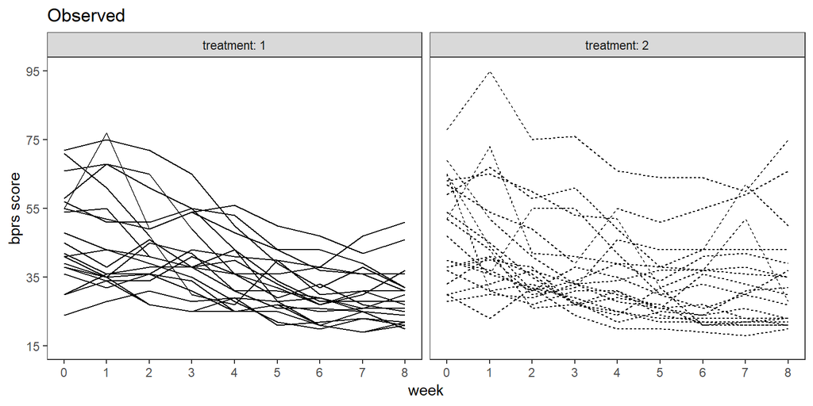

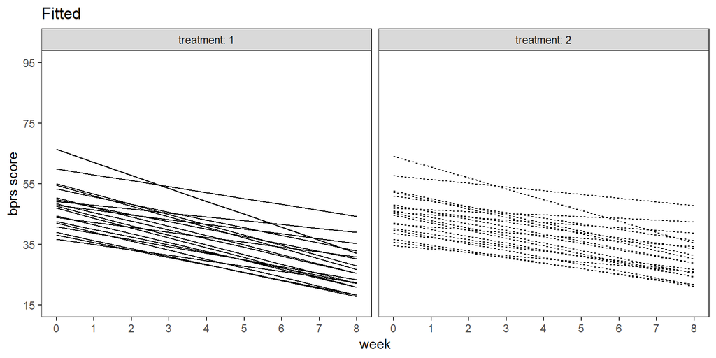

```r
Fitted <- fitted(BPRS_ref3)
BPRSL <- BPRSL %>% mutate(Fitted)
graph1 <- ggplot(BPRSL, aes(x = week, y = bprs, group = subject)) +
 geom_line(aes(linetype = treatment)) +
 scale_x_continuous(name = "week", breaks = seq(0, 8, 1)) +
 scale_y_continuous(name = "bprs score", limits= c(15,95), breaks = seq(15, 95, 20)) +
 theme_bw() + theme(legend.position = "none")  +
 theme(panel.grid.major = element_blank(), panel.grid.minor = element_blank()) +
 ggtitle("Observed") +
  facet_grid(. ~ treatment, labeller = label_both)


graph2 <- ggplot(BPRSL, aes(x = week, y = Fitted, group = subject)) +
 geom_line(aes(linetype = treatment)) +
 scale_x_continuous(name = "week", breaks = seq(0, 8, 1)) +
 scale_y_continuous(name = "bprs score", limits= c(15,95), breaks = seq(15, 95, 20)) +
 theme_bw() + theme(legend.position = "none")  +
 theme(panel.grid.major = element_blank(), panel.grid.minor = element_blank()) +
 ggtitle("Fitted") +
  facet_grid(. ~ treatment, labeller = label_both)

graph1; graph2
```

##### **FIGURE 9.4** Fitted changes in bprs scores from the interaction model and observed bprs changes